# Model Selection - Best Subset, Forward Stepwise selection using validation Set, Cross Validation

```r
library(ISLR)
```

This dataset was taken from the StatLib library which is maintained at Carnegie Mellon University. This is part of the data that was used in the 1988 ASA Graphics Section Poster Session. The salary data were originally from Sports Illustrated, April 20, 1987. The 1986 and career statistics were obtained from The 1987 Baseball Encyclopedia Update published by Collier Books, Macmillan Publishing Company, New York.

```r
summary(Hitters)
```

```
##      AtBat            Hits         HmRun            Runs
##  Min.   : 16.0   Min.   :  1   Min.   : 0.00   Min.   :  0.00
##  1st Qu.:255.2   1st Qu.: 64   1st Qu.: 4.00   1st Qu.: 30.25
##  Median :379.5   Median : 96   Median : 8.00   Median : 48.00
##  Mean   :380.9   Mean   :101   Mean   :10.77   Mean   : 50.91
##  3rd Qu.:512.0   3rd Qu.:137   3rd Qu.:16.00   3rd Qu.: 69.00
##  Max.   :687.0   Max.   :238   Max.   :40.00   Max.   :130.00
##
##       RBI             Walks            Years            CAtBat
##  Min.   :  0.00   Min.   :  0.00   Min.   : 1.000   Min.   :   19.0
##  1st Qu.: 28.00   1st Qu.: 22.00   1st Qu.: 4.000   1st Qu.:  816.8
##  Median : 44.00   Median : 35.00   Median : 6.000   Median : 1928.0
##  Mean   : 48.03   Mean   : 38.74   Mean   : 7.444   Mean   : 2648.7
##  3rd Qu.: 64.75   3rd Qu.: 53.00   3rd Qu.:11.000   3rd Qu.: 3924.2
##  Max.   :121.00   Max.   :105.00   Max.   :24.000   Max.   :14053.0
##
##      CHits            CHmRun           CRuns             CRBI
##  Min.   :   4.0   Min.   :  0.00   Min.   :   1.0   Min.   :   0.00
##  1st Qu.: 209.0   1st Qu.: 14.00   1st Qu.: 100.2   1st Qu.:  88.75
##  Median : 508.0   Median : 37.50   Median : 247.0   Median : 220.50
##  Mean   : 717.6   Mean   : 69.49   Mean   : 358.8   Mean   : 330.12
##  3rd Qu.:1059.2   3rd Qu.: 90.00   3rd Qu.: 526.2   3rd Qu.: 426.25
##  Max.   :4256.0   Max.   :548.00   Max.   :2165.0   Max.   :1659.00
##
##      CWalks        League  Division    PutOuts          Assists
##  Min.   :   0.00   A:175   E:157    Min.   :   0.0   Min.   :  0.0
##  1st Qu.:  67.25   N:147   W:165    1st Qu.: 109.2   1st Qu.:  7.0
##  Median : 170.50                    Median : 212.0   Median : 39.5
##  Mean   : 260.24                    Mean   : 288.9   Mean   :106.9
##  3rd Qu.: 339.25                    3rd Qu.: 325.0   3rd Qu.:166.0
##  Max.   :1566.00                    Max.   :1378.0   Max.   :492.0
##
##      Errors          Salary       NewLeague
##  Min.   : 0.00   Min.   :  67.5   A:176
##  1st Qu.: 3.00   1st Qu.: 190.0   N:146
##  Median : 6.00   Median : 425.0
##  Mean   : 8.04   Mean   : 535.9
##  3rd Qu.:11.00   3rd Qu.: 750.0
##  Max.   :32.00   Max.   :2460.0
##                  NA's   :59
```

We will predict salary for the players. But we have missing values here. In this case we will remove missing values. We can also impute the data with mean or median or mode depending on the distribution.

```
## [1] 59
```

```
## [1] 0
```

Best Subset Regression Here we go through all models of different subset sizes and looks for best in each size. 2^p models where p is number of predictors. Library ‘leaps’ can be used here

```r
library(leaps)
regfit.full=regsubsets(Salary~.,data= hitters)
summary(regfit.full)
```

```
## Subset selection object
## Call: regsubsets.formula(Salary ~ ., data = hitters)
## 19 Variables  (and intercept)
##            Forced in Forced out
## AtBat          FALSE      FALSE
## Hits           FALSE      FALSE
## HmRun          FALSE      FALSE
## Runs           FALSE      FALSE
## RBI            FALSE      FALSE
## Walks          FALSE      FALSE
## Years          FALSE      FALSE
## CAtBat         FALSE      FALSE
## CHits          FALSE      FALSE
## CHmRun         FALSE      FALSE
## CRuns          FALSE      FALSE
## CRBI           FALSE      FALSE
## CWalks         FALSE      FALSE
## LeagueN        FALSE      FALSE
## DivisionW      FALSE      FALSE
## PutOuts        FALSE      FALSE
## Assists        FALSE      FALSE
## Errors         FALSE      FALSE
## NewLeagueN     FALSE      FALSE
## 1 subsets of each size up to 8
## Selection Algorithm: exhaustive
##          AtBat Hits HmRun Runs RBI Walks Years CAtBat CHits CHmRun CRuns
## 1  ( 1 ) " "   " "  " "   " "  " " " "   " "   " "    " "   " "    " "
## 2  ( 1 ) " "   "*"  " "   " "  " " " "   " "   " "    " "   " "    " "
## 3  ( 1 ) " "   "*"  " "   " "  " " " "   " "   " "    " "   " "    " "
## 4  ( 1 ) " "   "*"  " "   " "  " " " "   " "   " "    " "   " "    " "
## 5  ( 1 ) "*"   "*"  " "   " "  " " " "   " "   " "    " "   " "    " "
## 6  ( 1 ) "*"   "*"  " "   " "  " " "*"   " "   " "    " "   " "    " "
## 7  ( 1 ) " "   "*"  " "   " "  " " "*"   " "   "*"    "*"   "*"    " "
## 8  ( 1 ) "*"   "*"  " "   " "  " " "*"   " "   " "    " "   "*"    "*"
##          CRBI CWalks LeagueN DivisionW PutOuts Assists Errors NewLeagueN
## 1  ( 1 ) "*"  " "    " "     " "       " "     " "     " "    " "
## 2  ( 1 ) "*"  " "    " "     " "       " "     " "     " "    " "
## 3  ( 1 ) "*"  " "    " "     " "       "*"     " "     " "    " "
## 4  ( 1 ) "*"  " "    " "     "*"       "*"     " "     " "    " "
## 5  ( 1 ) "*"  " "    " "     "*"       "*"     " "     " "    " "
## 6  ( 1 ) "*"  " "    " "     "*"       "*"     " "     " "    " "
## 7  ( 1 ) " "  " "    " "     "*"       "*"     " "     " "    " "
## 8  ( 1 ) " "  "*"    " "     "*"       "*"     " "     " "    " "
```

- indicates feature selected for that particular siz. by default we get for size 8

```r
#for all predictors.
regfit.full1=regsubsets(Salary~.,data= hitters,nvmax = 19)
reg.summary = summary(regfit.full1)
names(reg.summary)
```

```
## [1] "which"  "rsq"    "rss"    "adjr2"  "cp"     "bic"    "outmat" "obj"
```

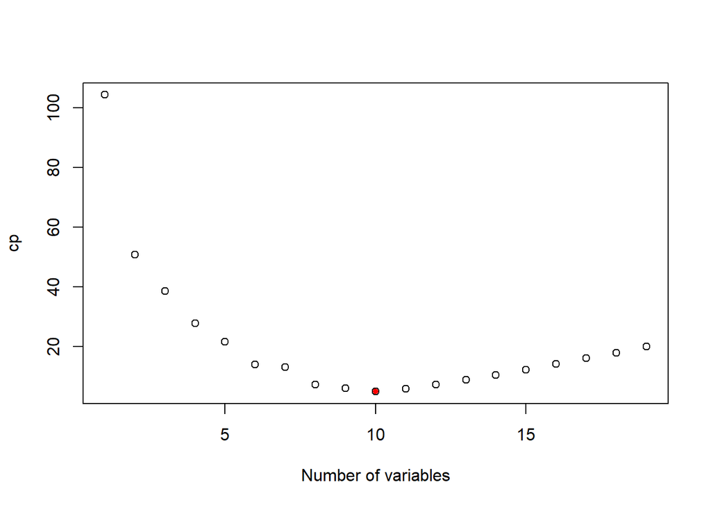

```r
mincp= which.min(reg.summary$cp)
plot(reg.summary$cp,xlab="Number of variables",ylab="cp")

points(mincp,reg.summary$cp[mincp],pch=20,col="red")
```

THe lowest prediction error is for 10 variable.

Using plot method for ‘regsubsets’ object

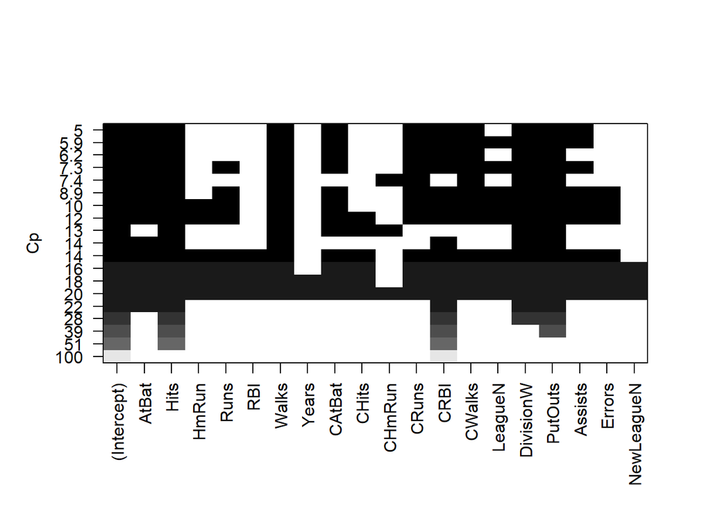

```r
plot(regfit.full1,scale="Cp")
```

The black one indicates In features and white indicates out features

```r
coef(regfit.full1,mincp)
```

```
##  (Intercept)        AtBat         Hits        Walks       CAtBat
##  162.5354420   -2.1686501    6.9180175    5.7732246   -0.1300798
##        CRuns         CRBI       CWalks    DivisionW      PutOuts
##    1.4082490    0.7743122   -0.8308264 -112.3800575    0.2973726
##      Assists
##    0.2831680
```

## Coefficients for 10 variables in the model.

Forward Stepwise selection - greedy algorithm. Each time it includes next best variable, but it produces in nested sequence

```r
regfit.fwd = regsubsets(Salary~.,data = hitters,nvmax = 19,method = "forward")
```

```r
summary(regfit.fwd)
```

```
## Subset selection object
## Call: regsubsets.formula(Salary ~ ., data = hitters, nvmax = 19, method = "forward")
## 19 Variables  (and intercept)
##            Forced in Forced out
## AtBat          FALSE      FALSE
## Hits           FALSE      FALSE
## HmRun          FALSE      FALSE
## Runs           FALSE      FALSE
## RBI            FALSE      FALSE
## Walks          FALSE      FALSE
## Years          FALSE      FALSE
## CAtBat         FALSE      FALSE
## CHits          FALSE      FALSE
## CHmRun         FALSE      FALSE
## CRuns          FALSE      FALSE
## CRBI           FALSE      FALSE
## CWalks         FALSE      FALSE
## LeagueN        FALSE      FALSE
## DivisionW      FALSE      FALSE
## PutOuts        FALSE      FALSE
## Assists        FALSE      FALSE
## Errors         FALSE      FALSE
## NewLeagueN     FALSE      FALSE
## 1 subsets of each size up to 19
## Selection Algorithm: forward
##           AtBat Hits HmRun Runs RBI Walks Years CAtBat CHits CHmRun CRuns
## 1  ( 1 )  " "   " "  " "   " "  " " " "   " "   " "    " "   " "    " "
## 2  ( 1 )  " "   "*"  " "   " "  " " " "   " "   " "    " "   " "    " "
## 3  ( 1 )  " "   "*"  " "   " "  " " " "   " "   " "    " "   " "    " "
## 4  ( 1 )  " "   "*"  " "   " "  " " " "   " "   " "    " "   " "    " "
## 5  ( 1 )  "*"   "*"  " "   " "  " " " "   " "   " "    " "   " "    " "
## 6  ( 1 )  "*"   "*"  " "   " "  " " "*"   " "   " "    " "   " "    " "
## 7  ( 1 )  "*"   "*"  " "   " "  " " "*"   " "   " "    " "   " "    " "
## 8  ( 1 )  "*"   "*"  " "   " "  " " "*"   " "   " "    " "   " "    "*"
## 9  ( 1 )  "*"   "*"  " "   " "  " " "*"   " "   "*"    " "   " "    "*"
## 10  ( 1 ) "*"   "*"  " "   " "  " " "*"   " "   "*"    " "   " "    "*"
## 11  ( 1 ) "*"   "*"  " "   " "  " " "*"   " "   "*"    " "   " "    "*"
## 12  ( 1 ) "*"   "*"  " "   "*"  " " "*"   " "   "*"    " "   " "    "*"
## 13  ( 1 ) "*"   "*"  " "   "*"  " " "*"   " "   "*"    " "   " "    "*"
## 14  ( 1 ) "*"   "*"  "*"   "*"  " " "*"   " "   "*"    " "   " "    "*"
```

[output cut: 10 more lines]

```
## 5  ( 1 )  "*"  " "    " "     "*"       "*"     " "     " "    " "
## 6  ( 1 )  "*"  " "    " "     "*"       "*"     " "     " "    " "
## 7  ( 1 )  "*"  "*"    " "     "*"       "*"     " "     " "    " "
## 8  ( 1 )  "*"  "*"    " "     "*"       "*"     " "     " "    " "
## 9  ( 1 )  "*"  "*"    " "     "*"       "*"     " "     " "    " "
## 10  ( 1 ) "*"  "*"    " "     "*"       "*"     "*"     " "    " "
## 11  ( 1 ) "*"  "*"    "*"     "*"       "*"     "*"     " "    " "
## 12  ( 1 ) "*"  "*"    "*"     "*"       "*"     "*"     " "    " "
## 13  ( 1 ) "*"  "*"    "*"     "*"       "*"     "*"     "*"    " "
## 14  ( 1 ) "*"  "*"    "*"     "*"       "*"     "*"     "*"    " "
## 15  ( 1 ) "*"  "*"    "*"     "*"       "*"     "*"     "*"    " "
## 16  ( 1 ) "*"  "*"    "*"     "*"       "*"     "*"     "*"    " "
## 17  ( 1 ) "*"  "*"    "*"     "*"       "*"     "*"     "*"    "*"
## 18  ( 1 ) "*"  "*"    "*"     "*"       "*"     "*"     "*"    "*"
## 19  ( 1 ) "*"  "*"    "*"     "*"       "*"     "*"     "*"    "*"
```

Each model contains all variables from previous model plus 1 new variable.

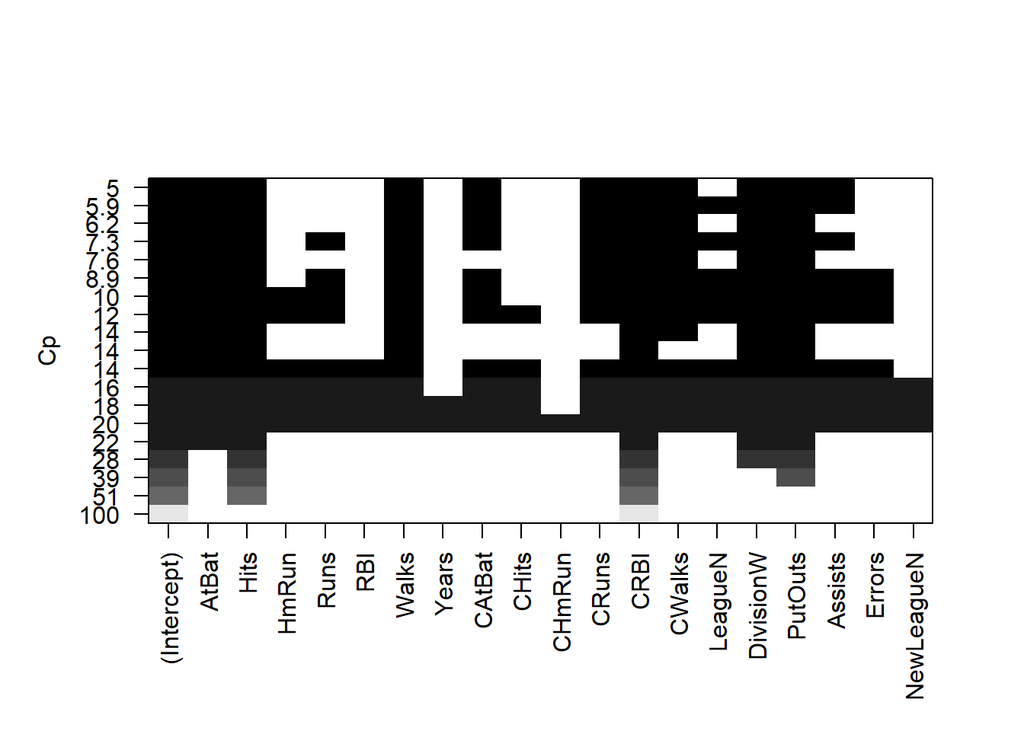

```r
plot(regfit.fwd,scale="Cp")
```

Similar structure like best subset. ———————————- Model Selection using validation set

```r
dim(hitters)
```

```
## [1] 263  20
```

```r
set.seed(1)
#2/3 train and 1/3 test
#sample from 263, 180 observations
train=sample(seq(263),180,replace=FALSE)
```

```r
regfit.fwdvs = regsubsets(Salary~.,data = hitters[train,],nvmax = 19,method = "forward")
```

Predictions on validation set Since we will have 19 models we use a vector to keep track of error.

```r
val.errors = rep(NA,19)
```

```r
x.test= model.matrix(Salary~.,data=hitters[-train,])
```

#no predict method for regsubset

```r
for(i in 1:19){
  coefi=coef(regfit.fwdvs,id = i)
  pred=x.test[,names(coefi)]%*%coefi #matrix multiply with coeffi vector
  val.errors[i]= mean((hitters$Salary[-train]-pred)^2)
}
```

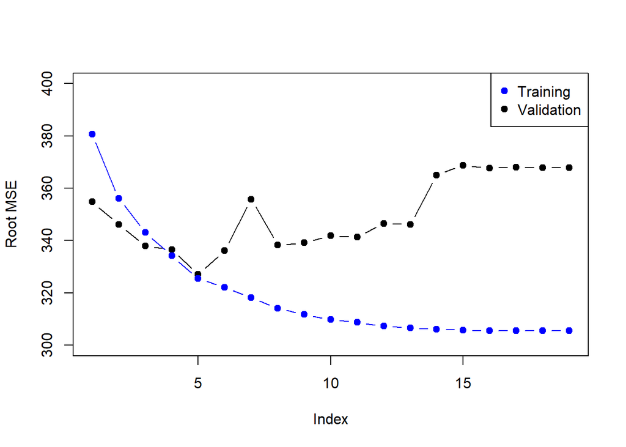

```r
plot(sqrt(val.errors),ylab = "Root MSE",ylim=c(300,400),pch=19,type="b")
#-1 removes the null model
points(sqrt(regfit.fwdvs$rss[-1]/180),col="blue",pch=19,type="b")
legend("topright",legend=c("Training","Validation"),col=c("blue","black"),pch=19)
```

The rss decreases as each time a new variable is included the fit of the model is improved on training data

Since we dont have predict method for regsubsets. Lets write a function for it

```r
predict.regsubsets=function(object,newdata,id,...){
  form=as.formula(object$call[[2]])
  testmat=model.matrix(form,newdata)
  coefi=coef(object,id=id)
  testmat[,names(coefi)]%*%coefi
}
```

Model Selection by Cross-validation - 10 fold

`r table(folds)`

taking column means as each row was mean squared error for a particular fold and then take root of it to get rmse for model with that number of variables.

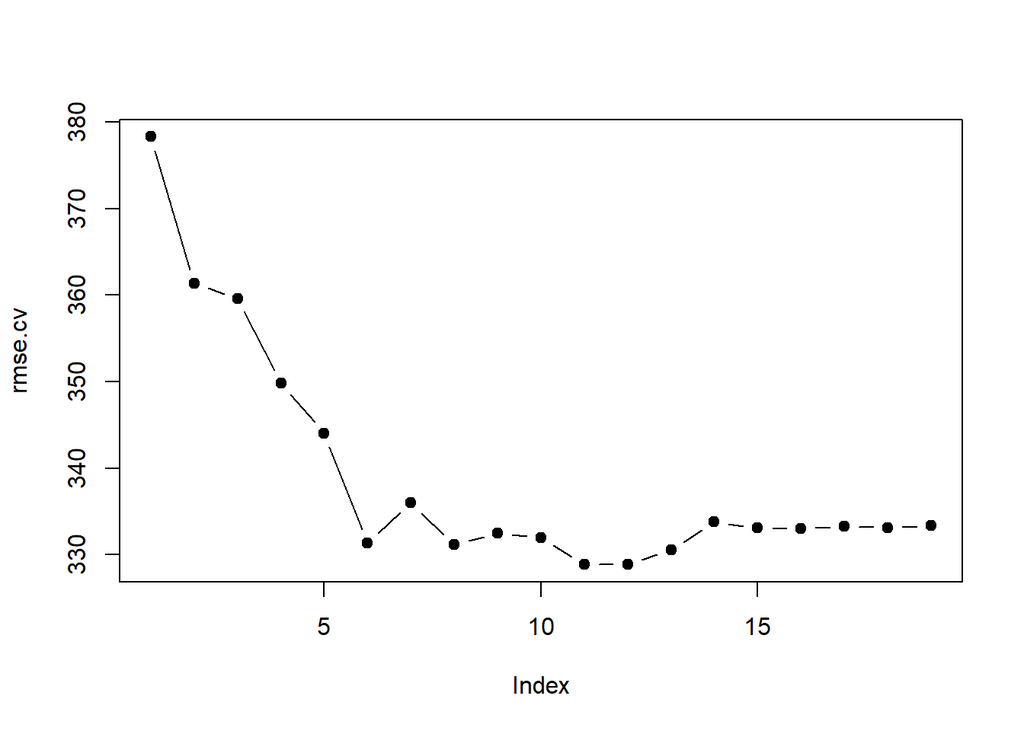

This erros are computed using full training set, done fold by fold and averaged. This seems to favor model size of 11 or 12.

Ridge Regression and Lasso Regression

```r
library(glmnet)
```

We need to provide matrix x of predictors and vector y to glmnet as it doesnot use formula

```r
X=model.matrix(Salary~.,-1,data=hitters)
y=hitters$Salary
```

Fitting a ridge regression model. using glmnet with alpha=0 for ridge (l2 norm) alpha=1 for lasso (l1 norm)

```r
fit.ridge = glmnet(X,y,alpha=0)
```

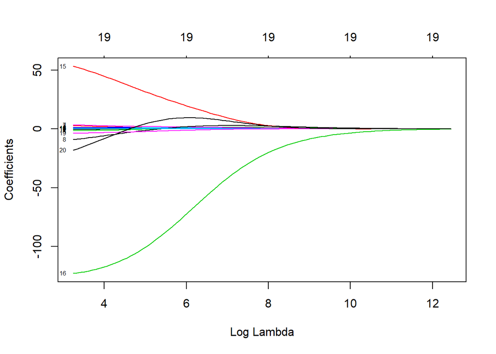

```r
plot(fit.ridge,xvar="lambda",label=TRUE)
```

It makes plot as a function of log of lambda with the co-efficients. lambda controls the penalty on coeffiecients where ridge regression is penalised by sum of squares of coefficients. As the lambda gets big the sum of squares of co-efficients shrinks to zero. So as we see on log scale when lambda =12 we have all the coeffiecients = 0, and as we relax lambda the co-efficient increase until lambda is 0 and coefficients are unregularized. Ridge Regression keeps all the variables in and shrink coefficients to zero where as best and forward stepwise selection controls the model complexity by restricting number of variables.

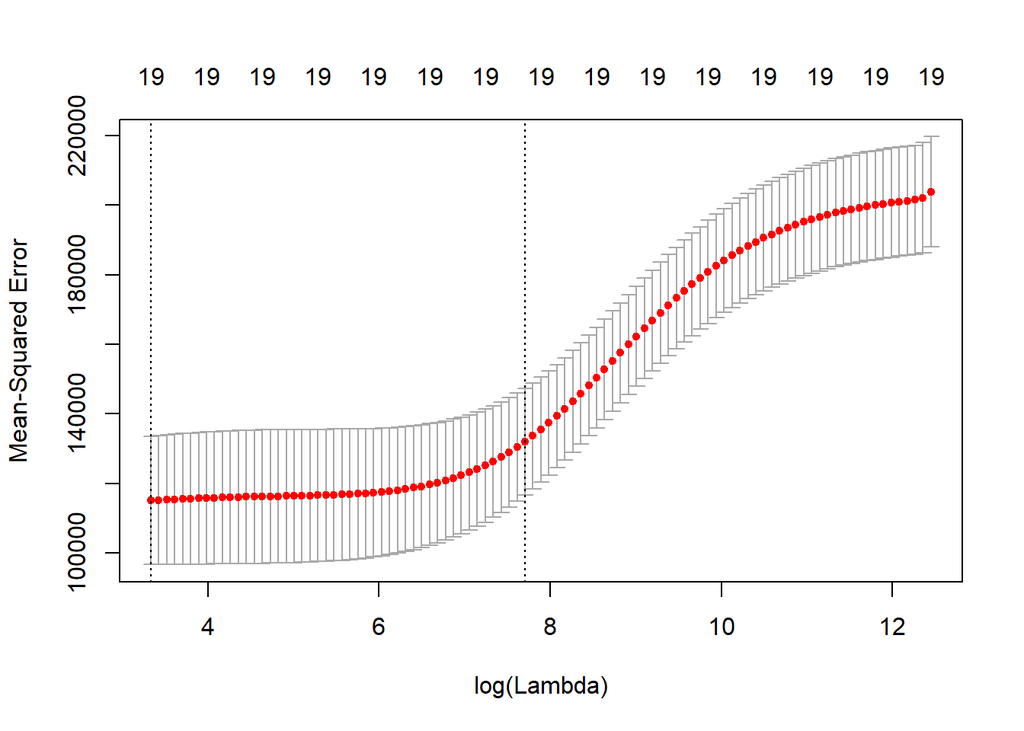

```r
#cross validation using glmnet, by default k =10
cv.ridge=cv.glmnet(X,y,alpha=0)
plot(cv.ridge)
```

The first line on the left indicates minimum error while other on right is at one standard error of minimum. As we can see there are all variables in the model.(19 variables)

Lasso - alpha =1 by default

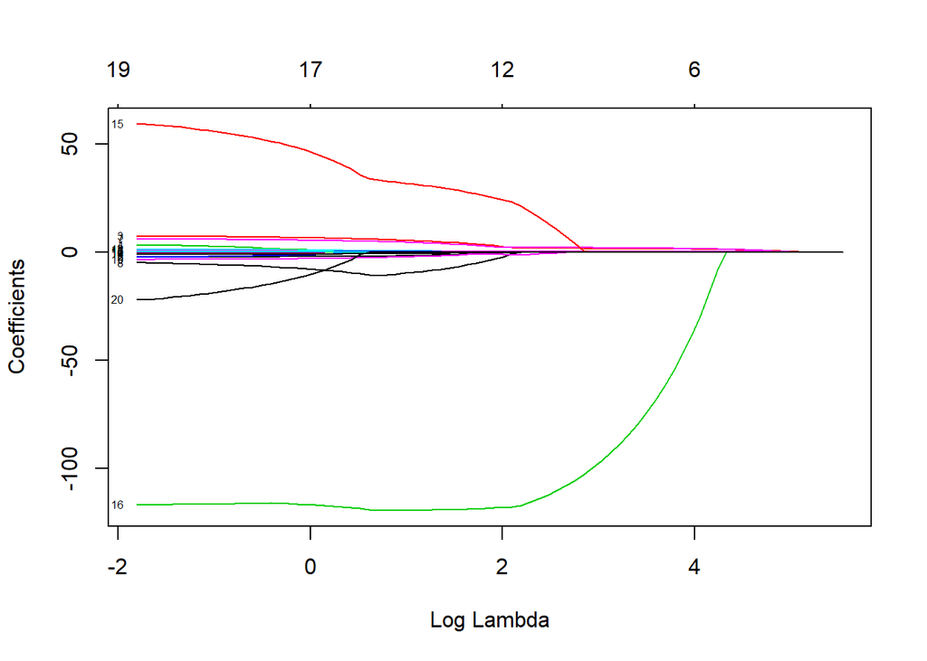

Initially all coeffiencts are zero. THen the first coefficient is the purple line and then green one jumps in and then red. At top of the plot we can see the number of variables in model as function of lambda. Lasso does variable selection and shrinkage of coeffiencts

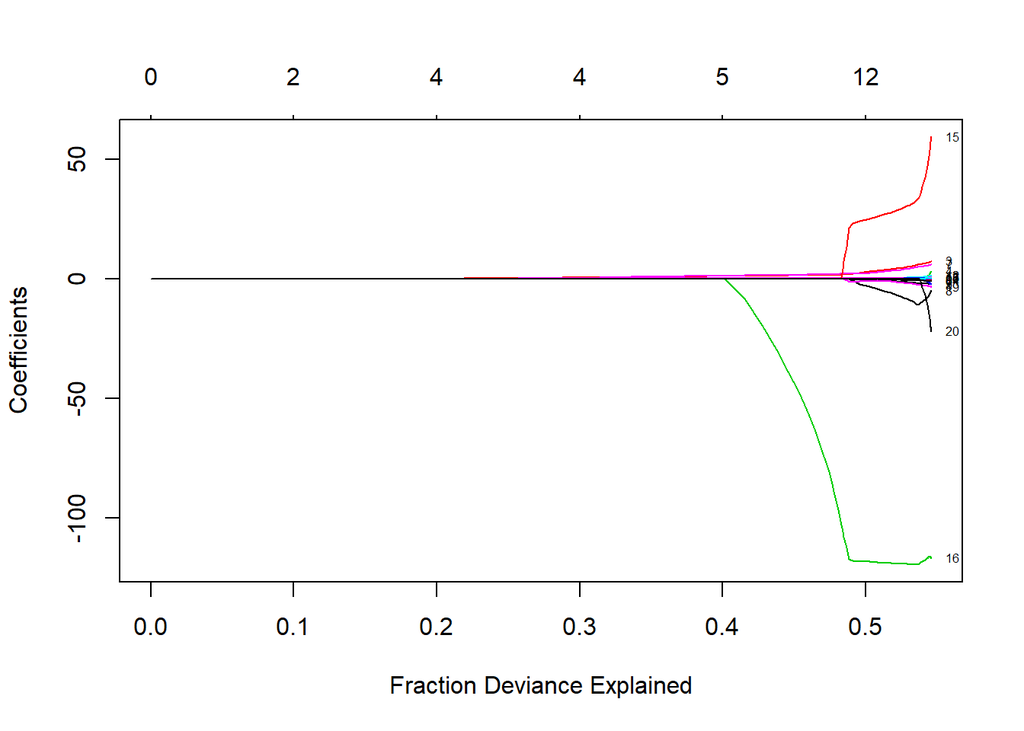

Now the orientation is different compare to lambda Fraction of Deviance explained is equivalent to r sqaured. As we can see a lot of r squared is explained for heavy shrinkage of coefficients. While after 0.4 or 0.5 towards the end the relatively small increase in r squared, co-efficients grow large. which may indicate overfitting at the end of the path.

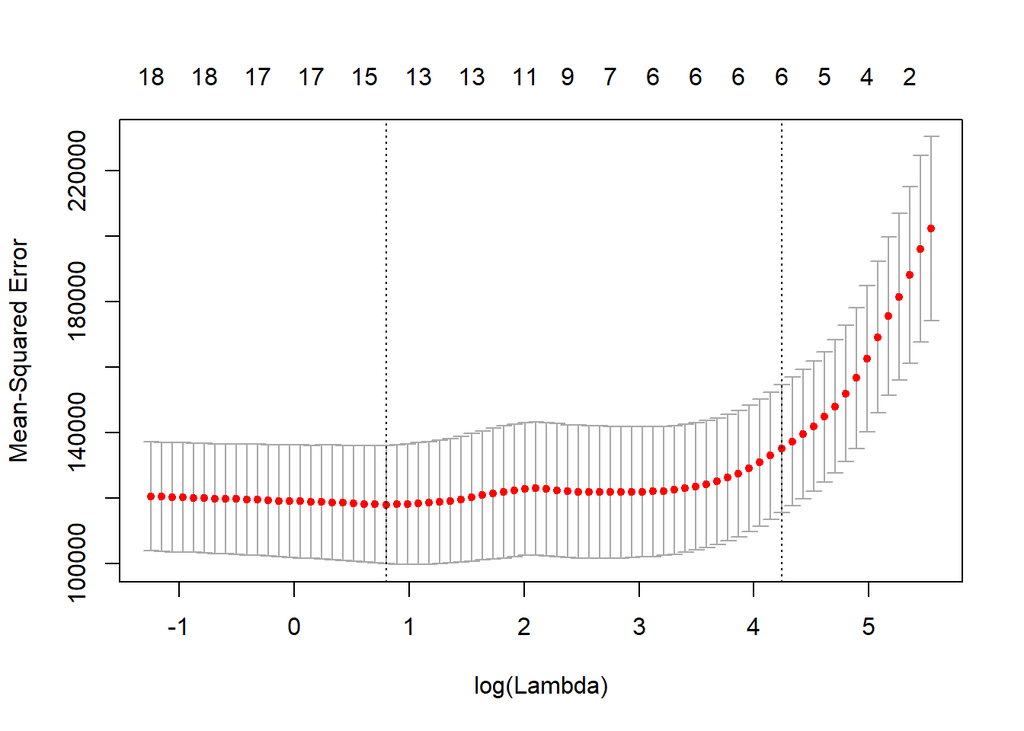

The minimum cross validation error is at model of size 15 and withing one standard error is at model of size 6 or 5

using train -validation division.

```r
lasso.train = glmnet(X[train,],y[train])
lasso.train
```

```
##
## Call:  glmnet(x = X[train, ], y = y[train])
##
##       Df    %Dev    Lambda
##  [1,]  0 0.00000 246.40000
##  [2,]  1 0.05013 224.50000
##  [3,]  1 0.09175 204.60000
##  [4,]  2 0.13840 186.40000
##  [5,]  2 0.18000 169.80000
##  [6,]  3 0.21570 154.80000
##  [7,]  3 0.24710 141.00000
##  [8,]  3 0.27320 128.50000
##  [9,]  4 0.30010 117.10000
## [10,]  4 0.32360 106.70000
## [11,]  4 0.34310  97.19000
```

[output cut: 78 more lines]

Degree of freedom, number of variables. it tries to predict for 100 values of lambda but we can see, there is no change in percentage deviation as lambda gets smaller, so it stops.

```r
predlasso = predict(lasso.train,X[-train,])
dim(predlasso)
```

```
## [1] 83 89
```

83 observations in validation set and 89 values of lambda.

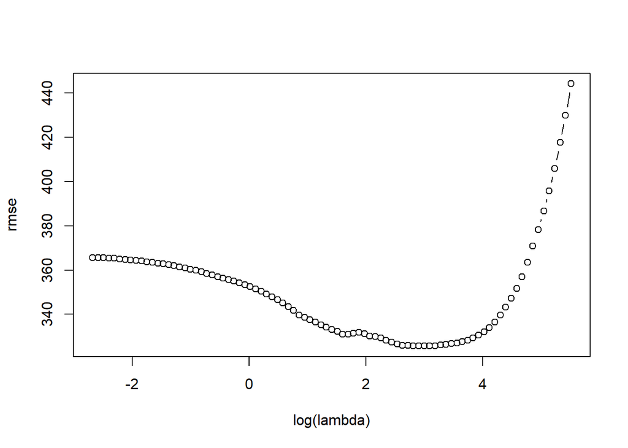

```r
#here y[-train] is a vector of 83 and pred is 83*89, here R recycles vector 89 times and column wise and gives result of matrix 83*89
rmse=sqrt(apply((y[-train]-predlasso)^2,2,mean))
plot(log(lasso.train$lambda),rmse,type="b",xlab="log(lambda)")
```

log(lambda) approx < 2 seems to be overfitting, > 4 underfitting while around 3 seems to be ideal value.

```r
#get lambda value for low rmse. we index the lambdas with order of rmse.
lambda.best=lasso.train$lambda[order(rmse)[1]]
lambda.best
```

```
## [1] 19.98706
```

```r
coef(lasso.train,s=lambda.best)
```

```
## 21 x 1 sparse Matrix of class "dgCMatrix"
##                        1
## (Intercept)   77.8923667
## (Intercept)    .
## AtBat          .
## Hits           0.1591252
## HmRun          .
## Runs           .
## RBI            1.7340039
## Walks          3.4657091
## Years          .
## CAtBat         .
## CHits          .
## CHmRun         .
## CRuns          0.5386855
## CRBI           .
## CWalks         .
## LeagueN       30.0493020
## DivisionW   -113.8317015
## PutOuts        0.2915409
## Assists        .
## Errors         .
## NewLeagueN     2.0367518
```